# The World is not Enough

Andrew Whitby

2 November 2016

The earth is a three-dimensional flattened sphere. Maps, on the other hand, are two-dimensional and usually rectangular. There is no unique best way to represent a sphere’s surface area on a two-dimensional plane. Something has to be sacrificed (e.g. accurate areas, or distances, or angles), and thus is born the art and science of map projections. Mathematically neat, a map projection describes exactly how the 3D surface points are projected onto the 2D map - say a wall map.

Maps in books are more complicated again. Books are not simple cartesian planes: they have margins, nonprintable areas, gutters, bindings, etc. These present extra problems for common map projections, the most obvious of which is that a half-dozen countries disappear into the binding.

[figure not shown]

Atlas of Global Development, 4th Ed

# Crevasse rescue

# Maximising aspect ratio

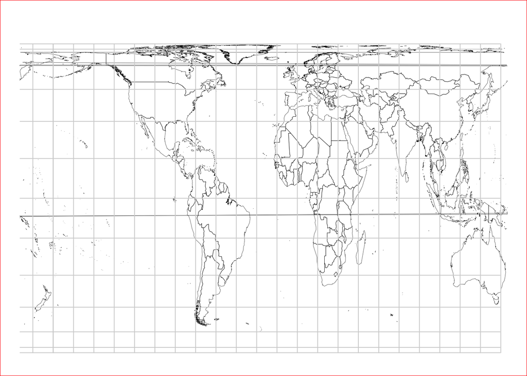